# Preprocessing & Feature Engineering and Classification Tree Example

We will use Credit Card Default Data for this lab and illustration. The business problem is to predict credit card default based on information about applicants. "response" is the response column that shows if they defaulted = 1 or did not default = 0.

## Step 0 — Load Data and EDA (we skip for now)

```python
import numpy as np
import pandas as pd
```

```python
df = pd.read_csv('Credit_Data_cleaning.csv')
#print(df.shape)
#print(df.describe(include='all'))
print(df['response'].value_counts())# summary stats

# Counts & percentages of missing values
missing_counts = df.isnull().sum()
missing_pct = (df.isnull().mean() * 100).round(2)

missing_summary = (
    pd.DataFrame({"n_missing": missing_counts, "pct_missing": missing_pct})
    .sort_values("pct_missing", ascending=False)
)

# Top 15 columns with most missing
missing_summary
```

```
response
0    9384
1    2634
Name: count, dtype: int64
```

|  | n_missing | pct_missing |
| --- | --- | --- |
| MARRIAGE | 31 | 0.26 |
| LIMIT_BAL | 0 | 0.00 |
| EDUCATION | 0 | 0.00 |
| AGE | 0 | 0.00 |
| PAY_0 | 0 | 0.00 |
| PAY_2 | 0 | 0.00 |
| PAY_3 | 0 | 0.00 |
| PAY_4 | 0 | 0.00 |
| PAY_5 | 0 | 0.00 |
| PAY_6 | 0 | 0.00 |
| BILL_AMT1 | 0 | 0.00 |
| BILL_AMT2 | 0 | 0.00 |
| BILL_AMT3 | 0 | 0.00 |
| BILL_AMT4 | 0 | 0.00 |
| BILL_AMT5 | 0 | 0.00 |
| BILL_AMT6 | 0 | 0.00 |
| PAY_AMT1 | 0 | 0.00 |
| PAY_AMT2 | 0 | 0.00 |
| PAY_AMT3 | 0 | 0.00 |
| PAY_AMT4 | 0 | 0.00 |
| PAY_AMT5 | 0 | 0.00 |
| PAY_AMT6 | 0 | 0.00 |
| response | 0 | 0.00 |

## Step 1 — Partitioning the data and prprocessing

### For classification problems, first determine the classes of your response variable and set them to integer with 1 as the event of interest. If the response is a string you will need to convert to integer with 1 being the event of interest.

```python
### For classification problems, first determine the classes of your response variable
print(df["response"].dtype)                     # what type is it?
print(df["response"].unique())                  # list of unique classes in the response variable
```

```
int64
[0 1]
```

```python
Y = (df["response"] == 1).astype(int) # returns True for rows where response == 1 and False otherwise then .astype(int) converts True→1 and False→0, so the “positive” label becomes 1
X = df.drop(columns=['response'])
```

### Train/test split and leakage (simple rule)

- You may create new engineered features **before splitting** only if it uses values from the same row. Example: counting how many months a customer was late using their own PAY columns.
- **Split first** whenever a step learns from the data (uses information from other rows of data) such as imputation, scaling, one-hot encoding, feature selection, PCA, model tuning. Fit those steps on the training set only (best done inside a Pipeline) to avoid leaking information from the test set.

```python
from sklearn.model_selection import train_test_split

# --- Feature engineering (based on the same row so it is safe to do BEFORE the train/test split) ---
# Example: number of months in the last 6 with late-payment status (PAY_* > 0)
pay_cols = ["PAY_0","PAY_2","PAY_3","PAY_4","PAY_5","PAY_6"]
df["months_late_6m"] = (df[pay_cols] > 0).sum(axis=1)

# Train/test split (stratified for classification)
X_train, X_test, Y_train, Y_test = train_test_split(
    X, Y, test_size=0.30, random_state=99, stratify=Y
)
```

Next do preprocessing steps that use many rows of the data such as imputation for missing values (uses the median of all observations in a column) **after splitting the data**.

Here we do the following:

```python
# Needed for preprocessing
from sklearn.compose import ColumnTransformer
from sklearn.pipeline import Pipeline
from sklearn.impute import SimpleImputer
from sklearn.preprocessing import OneHotEncoder


# 2) Identify column types from TRAIN ONLY
num_cols = X_train.select_dtypes(include=["number"]).columns.tolist()
cat_cols = X_train.select_dtypes(exclude=["number"]).columns.tolist()

# 3) Build preprocessing (train-only learning happens during .fit())
# numeric variable imputation
numeric_pipe = Pipeline([
    ("imputer", SimpleImputer(strategy="median"))
])

#categorical variable imputation
categorical_pipe = Pipeline([
    ("imputer", SimpleImputer(strategy="most_frequent")),
    ("onehot", OneHotEncoder(handle_unknown="warn", sparse_output=False))
])

#Aplpy the preprocessing to numeric and categorical variables
preprocess = ColumnTransformer([
    ("num", numeric_pipe, num_cols),
    ("cat", categorical_pipe, cat_cols)
])
```

## Step 2 — Train/ Fit Model: Classification Tree with Cross-Validation to choose best cp

```python
#Modeling portion
from sklearn.model_selection import StratifiedKFold
from sklearn.pipeline import Pipeline
from sklearn.model_selection import GridSearchCV
from sklearn.tree import DecisionTreeClassifier

cv = StratifiedKFold(n_splits=5, shuffle=True, random_state=10)

# Decision tree model
dt = DecisionTreeClassifier(random_state=42)

pipe = Pipeline([
    ("preprocess", preprocess),
    ("model", dt)
])

# cost complexity (cp) pruning parameter
param_grid = {
    "model__ccp_alpha": np.linspace(0.0, 0.005, 5),
}

grid = GridSearchCV(
    estimator=pipe, #model and preprocessing
    param_grid=param_grid, #tuning parameter values to try
    cv=cv,  #run cross validations
    scoring="roc_auc", #metric used in validation sets
    n_jobs=-1 #
)

# Fit learns preprocesssing, model TRAIN only
grid.fit(X_train, Y_train)

print("Best params:", grid.best_params_)
print("Best CV ROC-AUC:", round(grid.best_score_, 4))
```

```
Best params: {'model__ccp_alpha': np.float64(0.00125)}
Best CV ROC-AUC: 0.7398
```

```
num__PAY_0        0.760151
num__PAY_2        0.163424
num__PAY_AMT3     0.052133
num__PAY_5        0.024292
num__AGE          0.000000
num__PAY_3        0.000000
num__LIMIT_BAL    0.000000
num__PAY_6        0.000000
num__BILL_AMT1    0.000000
num__BILL_AMT2    0.000000
num__PAY_4        0.000000
num__BILL_AMT3    0.000000
num__BILL_AMT4    0.000000
num__BILL_AMT6    0.000000
num__BILL_AMT5    0.000000
num__PAY_AMT1     0.000000
num__PAY_AMT2     0.000000
num__PAY_AMT4     0.000000
num__PAY_AMT5     0.000000
num__PAY_AMT6     0.000000
dtype: float64
```

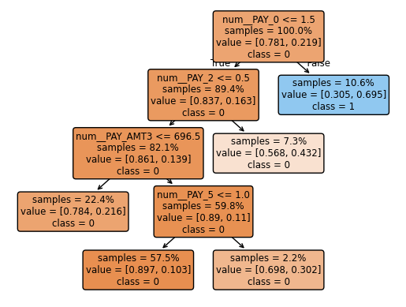

```python
best_pipe = grid.best_estimator_          # Pipeline(preprocess → DecisionTree) refit on all X_train
best_dt   = best_pipe.named_steps["model"] # The tuned DecisionTreeClassifier

#get important features
pre = best_pipe.named_steps["preprocess"]
feature_names = pre.get_feature_names_out()
imp = pd.Series(best_dt.feature_importances_, index=feature_names).sort_values(ascending=False)
display(imp.head(20))  # top 20 features


#plot tree
from sklearn import tree
import matplotlib.pyplot as plt


class_names = [str(c) for c in best_dt.classes_]

tree.plot_tree(
    best_dt,
    feature_names=feature_names, # names of predictor variables
    class_names=class_names, # Response variable needs to be a string for this
    filled=True,           # color nodes by majority class
    rounded=True,          # rounded boxes look nicer
    impurity=False,         # show Gini impurity (or entropy, depending on criterion)
    proportion=True,      # set True to show proportions instead of counts
    max_depth=5           # <-- for readability; shows top levels only
    # set True to show proportions instead of counts
   # max_depth=4
)
plt.show()
```

## Step 3: get predictions on the test set

best_pipe.predict_proba(X_test) first calls the already-fitted preprocess.transform(X_test):

- Missing numerics in X_test are filled with the train medians.
- Missing categoricals in X_test are filled with the train mode.
- Categories in X_test are encoded using train categories (unseen ones are ignored if handle_unknown="ignore").

```python
Y_prob = best_pipe.predict_proba(X_test)[:, 1]
```

## Step 4: Evaluate performance

```
Test ROC-AUC: 0.7403
```

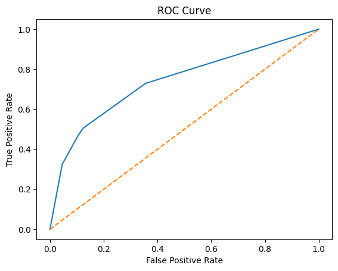

```python
# Needed for Evaluation
from sklearn.metrics import roc_auc_score, roc_curve
import matplotlib.pyplot as plt

# Test ROC-AUC
test_auc = roc_auc_score(Y_test, Y_prob)
print("Test ROC-AUC:", round(test_auc, 4))

# ROC curve (single plot; no custom colors)
fpr, tpr, _ = roc_curve(Y_test, Y_prob)
plt.plot(fpr, tpr)
plt.plot([0,1],[0,1],'--')
plt.xlabel('False Positive Rate')
plt.ylabel('True Positive Rate')
plt.title('ROC Curve')
plt.show()
```